# FordGoBike Data Exploration

## by Oluwafunmilayo Chinonye Samuel

## Introduction

This document explores a dataset containing information on a bike sharing system in the greater San Francisco Bay area for roughly 183, 000 rides for February, 2019 in order to generate worthy and interesting insights using univariate, bivariate, and multivariate exploration techniques. Some of the variables include the member birth year, gender, user type, trip duration, start and end station ids and names.

## Preliminary Wrangling

```python
# import all packages and set plots to be embedded inline
import numpy as np
import pandas as pd
import matplotlib.pyplot as plt
import seaborn as sb

%matplotlib inline
```

```python
# import the dataset
bike_df = pd.read_csv('201902-fordgobike.csv')
```

### Visual/Programmatic Assessment

```python
bike_df.shape
```

```
(183412, 16)
```

The dataset has 183,412 rows (observations), and 16 columns (variables)

```python
bike_df.sample(5)
```

|  | duration_sec | start_time | end_time | start_station_id | start_station_name | start_station_latitude | start_station_longitude | end_station_id | end_station_name | end_station_latitude | end_station_longitude | bike_id | user_type | member_birth_year | member_gender | bike_share_for_all_trip |
| --- | --- | --- | --- | --- | --- | --- | --- | --- | --- | --- | --- | --- | --- | --- | --- | --- |
| 13330 | 208 | 2019-02-27 16:27:43.1300 | 2019-02-27 16:31:11.4740 | 90.0 | Townsend St at 7th St | 37.771058 | -122.402717 | 91.0 | Berry St at King St | 37.771762 | -122.398438 | 6308 | Subscriber | NaN | NaN | No |
| 84793 | 742 | 2019-02-17 16:39:26.9070 | 2019-02-17 16:51:49.7380 | 371.0 | Lombard St at Columbus Ave | 37.802746 | -122.413579 | 9.0 | Broadway at Battery St | 37.798572 | -122.400869 | 6512 | Customer | 1995.0 | Male | No |
| 167019 | 912 | 2019-02-04 17:41:25.0780 | 2019-02-04 17:56:37.2060 | 24.0 | Spear St at Folsom St | 37.789677 | -122.390428 | 371.0 | Lombard St at Columbus Ave | 37.802746 | -122.413579 | 449 | Subscriber | 1973.0 | Male | No |
| 133843 | 1112 | 2019-02-08 18:05:51.4750 | 2019-02-08 18:24:24.0390 | 3.0 | Powell St BART Station (Market St at 4th St) | 37.786375 | -122.404904 | 355.0 | 23rd St at Tennessee St | 37.755367 | -122.388795 | 5381 | Subscriber | 1994.0 | Male | No |
| 91993 | 802 | 2019-02-15 20:40:42.1610 | 2019-02-15 20:54:04.6210 | 14.0 | Clay St at Battery St | 37.795001 | -122.399970 | 58.0 | Market St at 10th St | 37.776619 | -122.417385 | 1498 | Subscriber | 1991.0 | Male | No |

The column headers are very explanatory, although the data requires some basic feature engineering:

1. The trip duration, which is in seconds can be converted to hour for easier analysis.
2. A lot of insights can be gained by extracting the days of the week and time variables from the start_time column.
3. Converting the member_birth_year column to age will create easily understandable insight.
4. The distance between the start and end station can be gotten from the columns on latitudes and longitudes.

```python
# check for null values and duplicates
bike_df.isnull().sum().sum()
```

```
17318
```

There are 17318 null values.

```python
bike_df.duplicated().sum()
```

```
0
```

There are no duplicates in the bike dataset.

```python
bike_df.info()
```

```
<class 'pandas.core.frame.DataFrame'>
RangeIndex: 183412 entries, 0 to 183411
Data columns (total 16 columns):
duration_sec               183412 non-null int64
start_time                 183412 non-null object
end_time                   183412 non-null object
start_station_id           183215 non-null float64
start_station_name         183215 non-null object
start_station_latitude     183412 non-null float64
start_station_longitude    183412 non-null float64
end_station_id             183215 non-null float64
end_station_name           183215 non-null object
end_station_latitude       183412 non-null float64
end_station_longitude      183412 non-null float64
bike_id                    183412 non-null int64
user_type                  183412 non-null object
member_birth_year          175147 non-null float64
member_gender              175147 non-null object
bike_share_for_all_trip    183412 non-null object
dtypes: float64(7), int64(2), object(7)
memory usage: 22.4+ MB
```

There are some wrong datatypes:

1. start_time and end_time need to be changed from 'object' to 'timestamp'.
2. bike_id, start_station_id and end_station_id should be changed from 'int64' to 'object'.
3. member_birth_year should be changed from 'float64' to 'int64'

The null values are in the start and end station names/ids, and also in the gender and birthyear columns

### Cleaning

```python
# make a copy to avoid tampering with the original dataset
import copy
bike_df_copy = copy.deepcopy(bike_df)
```

```python
# drop the null values
bike_df_copy.dropna(inplace=True)

# test
bike_df_copy.isnull().sum().sum()
```

```
0
```

```python
# calculate the distance given latitudes and longitudes
# find code used here: https://gist.github.com/rochacbruno/2883505

import math
def calculateDistance(row):
    lat1 = row['start_station_latitude']
    lon1 = row['start_station_longitude']
    lat2 = row['end_station_latitude']
    lon2 = row['end_station_longitude']
    radius = 6371 # km radius of earth
    dlat = math.radians(lat2-lat1)
    dlon = math.radians(lon2-lon1)
    a = math.sin(dlat/2) * math.sin(dlat/2) + math.cos(math.radians(lat1)) \
        * math.cos(math.radians(lat2)) * math.sin(dlon/2) * math.sin(dlon/2)
    c = 2 * math.atan2(math.sqrt(a), math.sqrt(1-a))
    d = radius * c
    return d

# create a new column, distance from the defined function
bike_df_copy['distance'] = bike_df_copy.apply(lambda row: calculateDistance(row), axis=1)

# test
bike_df_copy.head(3)
```

|  | duration_sec | start_time | end_time | start_station_id | start_station_name | start_station_latitude | start_station_longitude | end_station_id | end_station_name | end_station_latitude | end_station_longitude | bike_id | user_type | member_birth_year | member_gender | bike_share_for_all_trip | distance |
| --- | --- | --- | --- | --- | --- | --- | --- | --- | --- | --- | --- | --- | --- | --- | --- | --- | --- |
| 0 | 52185 | 2019-02-28 17:32:10.1450 | 2019-03-01 08:01:55.9750 | 21.0 | Montgomery St BART Station (Market St at 2nd St) | 37.789625 | -122.400811 | 13.0 | Commercial St at Montgomery St | 37.794231 | -122.402923 | 4902 | Customer | 1984.0 | Male | No | 0.544709 |
| 2 | 61854 | 2019-02-28 12:13:13.2180 | 2019-03-01 05:24:08.1460 | 86.0 | Market St at Dolores St | 37.769305 | -122.426826 | 3.0 | Powell St BART Station (Market St at 4th St) | 37.786375 | -122.404904 | 5905 | Customer | 1972.0 | Male | No | 2.704545 |
| 3 | 36490 | 2019-02-28 17:54:26.0100 | 2019-03-01 04:02:36.8420 | 375.0 | Grove St at Masonic Ave | 37.774836 | -122.446546 | 70.0 | Central Ave at Fell St | 37.773311 | -122.444293 | 6638 | Subscriber | 1989.0 | Other | No | 0.260739 |

```python
# create a new column for duration in hours
bike_df_copy['duration_hr'] = bike_df_copy['duration_sec'] / 3600

# create a new column for age and convert the datatype to integer
bike_df_copy['age'] = (2019 - bike_df_copy['member_birth_year']).astype(int)

# change start_time's datatype to datetime
bike_df_copy.start_time = bike_df_copy.apply(lambda row: pd.to_datetime(row.start_time), axis=1)

# extract day of week and month as seperate columns
bike_df_copy['day_name'] = bike_df_copy.apply(lambda row: row.start_time.day_name(), axis = 1)
bike_df_copy['month'] = bike_df_copy.apply(lambda row: row.start_time.month_name(), axis = 1)

# order the categories for day_name
cats = [ 'Monday', 'Tuesday', 'Wednesday', 'Thursday', 'Friday', 'Saturday', 'Sunday']
bike_df_copy['day_name'] = bike_df_copy['day_name'].astype('category', categories=cats, ordered=True)

#test
bike_df_copy.info()
```

```
<class 'pandas.core.frame.DataFrame'>
Int64Index: 174952 entries, 0 to 183411
Data columns (total 21 columns):
duration_sec               174952 non-null int64
start_time                 174952 non-null datetime64[ns]
end_time                   174952 non-null object
start_station_id           174952 non-null float64
start_station_name         174952 non-null object
start_station_latitude     174952 non-null float64
start_station_longitude    174952 non-null float64
end_station_id             174952 non-null float64
end_station_name           174952 non-null object
end_station_latitude       174952 non-null float64
end_station_longitude      174952 non-null float64
bike_id                    174952 non-null int64
user_type                  174952 non-null object
member_birth_year          174952 non-null float64
member_gender              174952 non-null object
bike_share_for_all_trip    174952 non-null object
distance                   174952 non-null float64
duration_hr                174952 non-null float64
age                        174952 non-null int64
day_name                   174952 non-null category
month                      174952 non-null object
dtypes: category(1), datetime64[ns](1), float64(9), int64(3), object(7)
memory usage: 28.2+ MB
```

```python
bike_df_copy.month.value_counts()
```

```
February    174952
Name: month, dtype: int64
```

The created columns have been added, and the identified datatypes have been changed. The month column reveals that dataset represents bike share rides for the month of February, 2019.

```python
# define a function to categorize time as shown below
def getTimeOfDay(time):
    hour = time.hour
    if hour >= 6 and hour <= 12:
        return 'morning'
    if hour > 12 and hour <= 16:
        return 'afternoon'
    if hour > 16 and hour <= 20:
        return 'early evening'
    if hour > 20 and hour <= 23:
        return 'late evening'
    if hour >= 0 and hour < 6:
        return 'night'

# create a column for time with the defined categories
bike_df_copy['time'] = bike_df_copy['start_time'].apply(lambda time: getTimeOfDay(time)).astype('category')

# order the categories
cats = [ 'morning', 'afternoon', 'early evening', 'late evening', 'night']
bike_df_copy['time'] = bike_df_copy['time'].astype('category', categories=cats, ordered=True)

# test
bike_df_copy.head(3)
```

|  | duration_sec | start_time | end_time | start_station_id | start_station_name | start_station_latitude | start_station_longitude | end_station_id | end_station_name | end_station_latitude | ... | user_type | member_birth_year | member_gender | bike_share_for_all_trip | distance | duration_hr | age | day_name | month | time |
| --- | --- | --- | --- | --- | --- | --- | --- | --- | --- | --- | --- | --- | --- | --- | --- | --- | --- | --- | --- | --- | --- |
| 0 | 52185 | 2019-02-28 17:32:10.145 | 2019-03-01 08:01:55.9750 | 21.0 | Montgomery St BART Station (Market St at 2nd St) | 37.789625 | -122.400811 | 13.0 | Commercial St at Montgomery St | 37.794231 | ... | Customer | 1984.0 | Male | No | 0.544709 | 14.495833 | 35 | Thursday | February | early evening |
| 2 | 61854 | 2019-02-28 12:13:13.218 | 2019-03-01 05:24:08.1460 | 86.0 | Market St at Dolores St | 37.769305 | -122.426826 | 3.0 | Powell St BART Station (Market St at 4th St) | 37.786375 | ... | Customer | 1972.0 | Male | No | 2.704545 | 17.181667 | 47 | Thursday | February | morning |
| 3 | 36490 | 2019-02-28 17:54:26.010 | 2019-03-01 04:02:36.8420 | 375.0 | Grove St at Masonic Ave | 37.774836 | -122.446546 | 70.0 | Central Ave at Fell St | 37.773311 | ... | Subscriber | 1989.0 | Other | No | 0.260739 | 10.136111 | 30 | Thursday | February | early evening |

3 rows × 22 columns

```python
# create Weekday and Weekend categories
conditions = [
    bike_df_copy.day_name.isin(['Monday', 'Tuesday', 'Wednesday', 'Thursday', 'Friday']),
    bike_df_copy.day_name.isin(['Saturday', 'Sunday']),
]

values = ['Weekday', 'Weekend']

# create a new column with the defined conditions and values
bike_df_copy['day_week'] = np.select(conditions, values)

#test
assert 'day_week' in bike_df_copy.columns
```

The column has been successfully added.

```python
# drop the unnecessary columns
bike_df_copy.drop(['duration_sec', 'start_time', 'end_time', 'start_station_longitude', 'start_station_latitude',
                   'end_station_latitude', 'end_station_longitude', 'member_birth_year', 'month'], axis=1, inplace=True)

# rename member_gender
bike_df_copy.rename(columns = {'member_gender':'gender'}, inplace=True)

# change the identified datatypes
bike_df_copy = bike_df_copy.astype({'start_station_id':'object', 'end_station_id':'object', 'bike_id':'object'})

#test
bike_df_copy.info()
```

```
<class 'pandas.core.frame.DataFrame'>
Int64Index: 174952 entries, 0 to 183411
Data columns (total 14 columns):
start_station_id           174952 non-null object
start_station_name         174952 non-null object
end_station_id             174952 non-null object
end_station_name           174952 non-null object
bike_id                    174952 non-null object
user_type                  174952 non-null object
gender                     174952 non-null object
bike_share_for_all_trip    174952 non-null object
distance                   174952 non-null float64
duration_hr                174952 non-null float64
age                        174952 non-null int64
day_name                   174952 non-null category
time                       174952 non-null category
day_week                   174952 non-null object
dtypes: category(2), float64(2), int64(1), object(9)
memory usage: 17.7+ MB
```

```python
print(bike_df_copy.start_station_id.nunique())
print(bike_df_copy.end_station_name.nunique())
print(bike_df_copy.bike_id.nunique())
```

```
329
329
4607
```

### What is the structure of your dataset?

The dataset contains 174952 bike share rides with 14 columns. Below is a brief description of each column variable:

1. start_station_id - 329 unique ids
2. start_station_name - 329 unique names
3. end_station_id - 329 unique ids
4. end_station_name - 329 unique names
5. bike_id - 4607 unique ids
6. user_type - Customer or Subscriber
7. gender - Male, Female or Other
8. bike_share_for_all_trip - Yes or No
9. distance - distance between start and end stations
10. duration_hr - trip duration in hours
11. age - age of the member
12. day_name - Monday, Tuesday, Wednesday, Thursday, Friday, Saturday, Sunday
13. time - morning, afternoon, early evening, late evening, night
14. day_week - Weekday or Weekend

Majority of the variables are categorical, and there are three numeric variables (distance, duration_hr, and age).

### What is/are the main feature(s) of interest in your dataset?

I am most interested in understanding the differences between the bike sharers on the basis of their user type.

### What features in the dataset do you think will help support your investigation into your feature(s) of interest?

I would like to consider the age, duration_hr, time, gender, distance, day_name, and day_week.

## Univariate Exploration

I will begin with the exploration of numerical variables, and continue with the categorical variables including my variable of interest (user_type).

### 1. What is the distribution of age?

```python
# set color palette
sb.set_palette('Set2')
```

```python
# get an overall view of the numerical variables in the dataset
bike_df_copy.describe()
```

|  | distance | duration_hr | age |
| --- | --- | --- | --- |
| count | 174952.000000 | 174952.000000 | 174952.000000 |
| mean | 1.690049 | 0.195556 | 34.196865 |
| std | 1.096957 | 0.456168 | 10.118731 |
| min | 0.000000 | 0.016944 | 18.000000 |
| 25% | 0.910443 | 0.089722 | 27.000000 |
| 50% | 1.429829 | 0.141667 | 32.000000 |
| 75% | 2.224010 | 0.219167 | 39.000000 |
| max | 69.469241 | 23.485556 | 141.000000 |

The maximum age is 141 years, the minimum age is 18 years, the median age is 32 and the mean age is approximately 34 years. The maximum age indicates that there might be statistically significant outliers which can introduce error or bias in the exploration results. The statistical formula to determine low and high outliers are (Q1 - 1.5.IQR) and (Q3 + 1.5.IQR) respectively.

NB: Q1 - first quartile (25%), Q3 - third quartile (75%), and IQR = Q3 - Q1

```python
# define a function to plot histograms
def histogram(Dataframe, x_values, x_label, y_label, bins):
    plt.hist(data = Dataframe, x = x_values, bins = bins);
    plt.xlabel(x_label)
    plt.ylabel(y_label)
    plt.show()
```

```python
# define a function to plot boxplots
def boxplot(Dataframe, x_values, x_label):
    Dataframe.boxplot(column = x_values, vert = False);
    plt.xlabel(x_label)
```

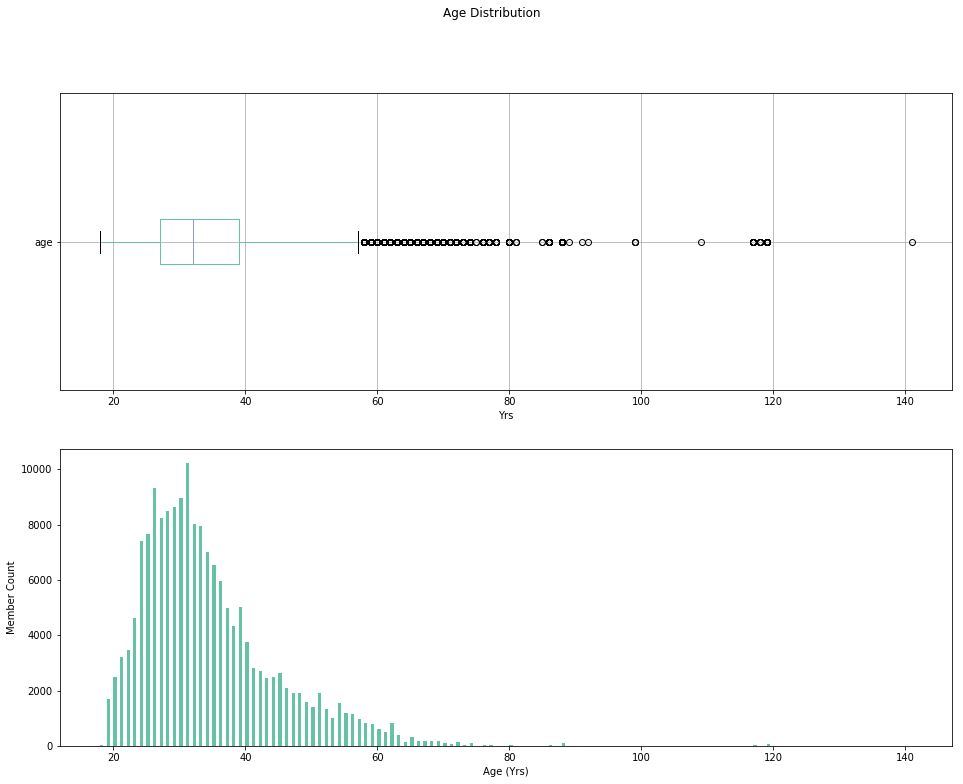

```python
# visualize the age distribution using a boxplot and a histogram
fig, axes = plt.subplots(2, 1, figsize=(16,12));
fig.suptitle('Age Distribution');

plt.subplot(2, 1, 1)
boxplot(bike_df_copy, 'age', 'Yrs')

plt.subplot(2, 1, 2)
binsize = 0.5
bins = np.arange(18, bike_df_copy['age'].max()+binsize, binsize)

histogram(bike_df_copy, 'age', 'Age (Yrs)', 'Member Count', bins)
```

```python
# determine the statistical data range
# from the output of .describe(), Q1 and Q3 for age are 27 and 39 respectively.
low_outliers_value = 27 - (1.5*12)
high_outliers_value = 39 + (1.5*12)

print(low_outliers_value)
print(high_outliers_value)
```

```
9.0
57.0
```

The minimum age is 18 years, and this implies that there are no low outliers for age. However, there are high outliers based on the statistical high_outliers value.

```python
# select high outliers, using statistical criteria

high_outliers_57 = (bike_df_copy['age'] > 57)
print(bike_df_copy.loc[high_outliers_57,:])
```

```
       start_station_id                                 start_station_name  \
5                    93                       4th St at Mission Bay Blvd S
43                  104                                  4th St at 16th St
67                   43  San Francisco Public Library (Grove St at Hyde...
203                  76                         McCoppin St at Valencia St
307                 149                               Emeryville Town Hall
495                  34                     Father Alfred E Boeddeker Park
505                  21   Montgomery St BART Station (Market St at 2nd St)
661                 245                             Downtown Berkeley BART
683                  13                     Commercial St at Montgomery St
708                 105                              16th St at Prosper St
765                 170                           Telegraph Ave at 58th St
772                 201                               10th St at Fallon St
796                  96                              Dolores St at 15th St
838                 323                                 Broadway at Kearny
```

[output cut: 238 more lines]

5781 observations are high outliers for the age variable. This represents a large part of the dataset. Instead of removing all the statistical outliers, I will select extreme outliers based on the boxplot and histogram.

```python
# select high outliers, using visualizations
# extreme outliers based on the plot are age values >80yrs

high_outliers_80 = (bike_df_copy['age'] > 80)
print(bike_df_copy.loc[high_outliers_80,:])
```

```
       start_station_id                                 start_station_name  \
1285                158                      Shattuck Ave at Telegraph Ave
5197                 70                             Central Ave at Fell St
5266                 84                                        Duboce Park
5447                 84                                        Duboce Park
10827               343                                Bryant St at 2nd St
16087               375                            Grove St at Masonic Ave
17981                50                              2nd St at Townsend St
18885                21   Montgomery St BART Station (Market St at 2nd St)
19375                 9                             Broadway at Battery St
20743                26                                1st St at Folsom St
21424               375                            Grove St at Masonic Ave
21506                67  San Francisco Caltrain Station 2  (Townsend St...
24042               158                      Shattuck Ave at Telegraph Ave
26133               173                            Shattuck Ave at 55th St
```

[output cut: 238 more lines]

There are only 192 outliers. These extreme outliers will be dropped.

```python
# drop the outliers
bike_df_copy = bike_df_copy.loc[-high_outliers_80]
```

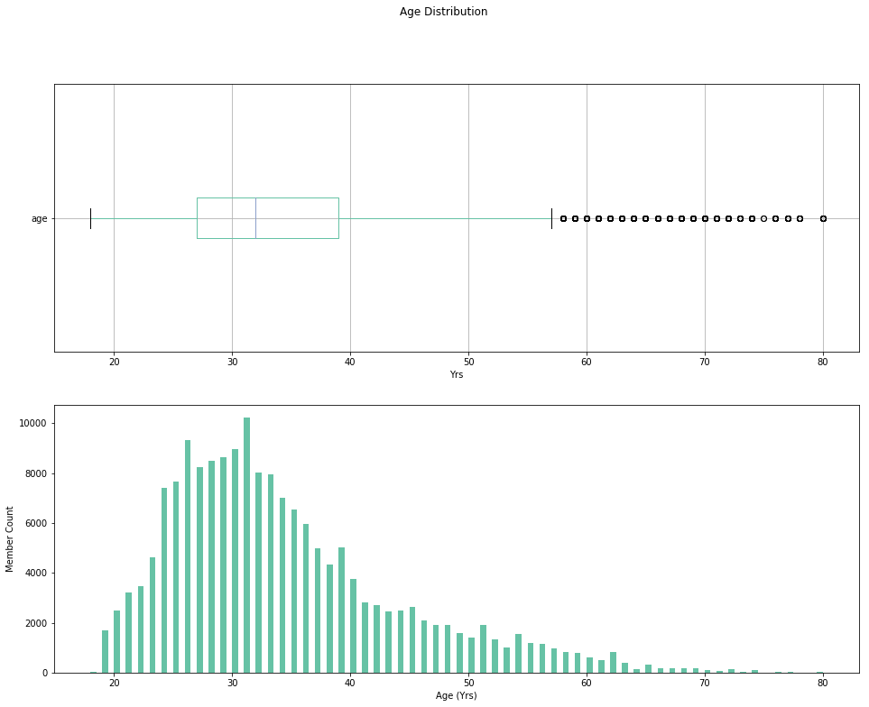

```python
# visualize the age distribution for the new dataset
fig, axes = plt.subplots(2, 1, figsize=(16,12));
fig.suptitle('Age Distribution');

plt.subplot(2, 1, 1)
boxplot(bike_df_copy, 'age', 'Yrs')

plt.subplot(2, 1, 2)
binsize = 0.5
bins = np.arange(18, bike_df_copy['age'].max()+binsize, binsize)
histogram(bike_df_copy, 'age', 'Age (Yrs)', 'Member Count', bins)
```

```python
bike_df_copy.describe()
```

|  | distance | duration_hr | age |
| --- | --- | --- | --- |
| count | 174760.000000 | 174760.000000 | 174760.000000 |
| mean | 1.690465 | 0.195642 | 34.125223 |
| std | 1.096668 | 0.456398 | 9.877739 |
| min | 0.000000 | 0.016944 | 18.000000 |
| 25% | 0.910955 | 0.089722 | 27.000000 |
| 50% | 1.429829 | 0.141944 | 32.000000 |
| 75% | 2.224610 | 0.219167 | 39.000000 |
| max | 69.469241 | 23.485556 | 80.000000 |

The plot still shows that the age distribution is extremely skewed to the right. However, it is unimodal with one peak point at 31 years. The values of the mean (34years), mode (31years) and median (32years) are close. Additionally, the distribution is logical based on the number of trips. Younger people generally bike more than older people. Therefore, I will not perform a transformation on this variable.

### 2. What is the distribution of trip duration?

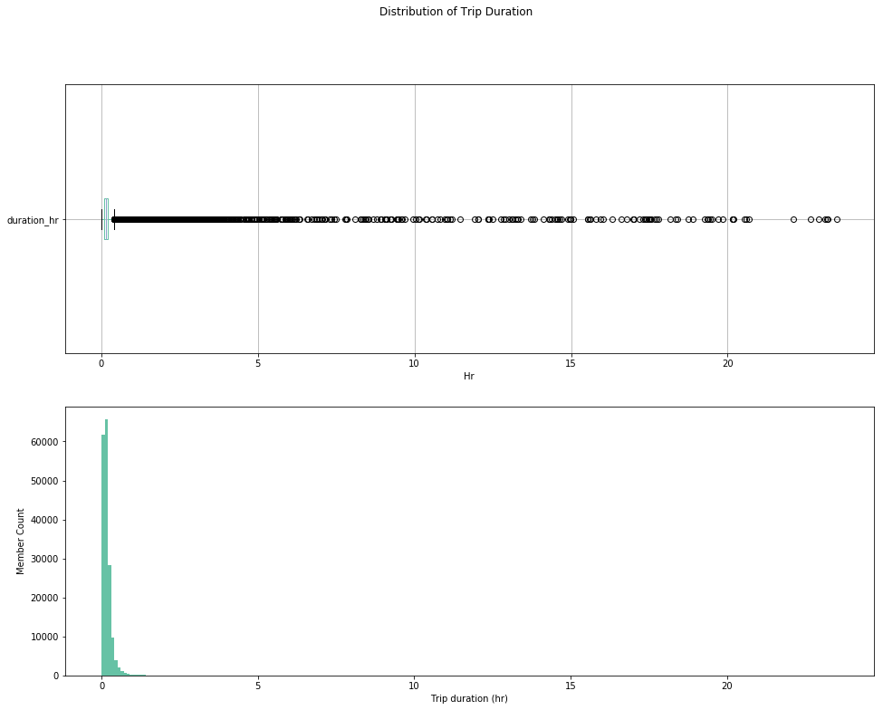

```python
# visualize the trip distribution using a boxplot and a histogram
fig, axes = plt.subplots(2, 1, figsize=(16,12));
fig.suptitle('Distribution of Trip Duration');

plt.subplot(2, 1, 1)
boxplot(bike_df_copy, 'duration_hr', 'Hr')

plt.subplot(2, 1, 2)
binsize = 0.1
bins = np.arange(0.01, bike_df_copy['duration_hr'].max()+binsize, binsize)
histogram(bike_df_copy, 'duration_hr', 'Trip duration (hr)', 'Member Count', bins)
```

The distribution of trip duration is also extremely skewed to the right, although unimodal with a peak around 0.1. The histogram also shows that there are significant high outliers, and this can affect the result of the exploratory analysis. Therefore, I will remove the outliers based on the plot.

```python
# select high outliers, using visualizations
# extreme outliers based on the plot are trip durations > 1.5hrs

high_outliers_2 = (bike_df_copy['duration_hr'] > 1.5)
print(bike_df_copy.loc[high_outliers_2,:])
```

```
       start_station_id                                 start_station_name  \
0                    21   Montgomery St BART Station (Market St at 2nd St)
2                    86                            Market St at Dolores St
3                   375                            Grove St at Masonic Ave
91                  252                       Channing Way at Shattuck Ave
199                  28                       The Embarcadero at Bryant St
297                  19                               Post St at Kearny St
511                 266                             Parker St at Fulton St
524                  66                              3rd St at Townsend St
779                  58                               Market St at 10th St
790                   5       Powell St BART Station (Market St at 5th St)
813                 241                                 Ashby BART Station
939                   5       Powell St BART Station (Market St at 5th St)
945                   5       Powell St BART Station (Market St at 5th St)
1826                284  Yerba Buena Center for the Arts (Howard St at ...
```

[output cut: 238 more lines]

```python
# drop the outliers
bike_df_copy = bike_df_copy.loc[-high_outliers_2]
```

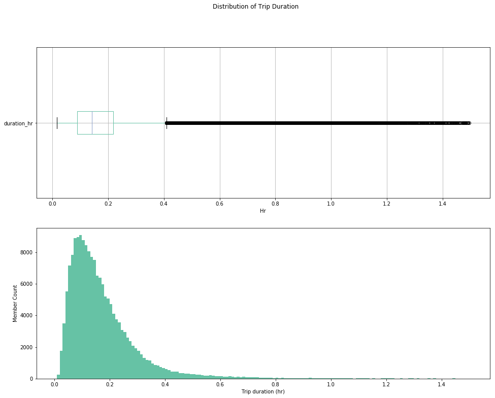

```python
# visualize the trip distribution for the new dataset
fig, axes = plt.subplots(2, 1, figsize=(16,12));
fig.suptitle('Distribution of Trip Duration');

plt.subplot(2, 1, 1)
boxplot(bike_df_copy, 'duration_hr', 'Hr')

plt.subplot(2, 1, 2)
binsize = 0.01
bins = np.arange(0.01, bike_df_copy['duration_hr'].max()+binsize, binsize)
histogram(bike_df_copy, 'duration_hr', 'Trip duration (hr)', 'Member Count', bins)
```

```python
bike_df_copy.describe()
```

|  | distance | duration_hr | age |
| --- | --- | --- | --- |
| count | 173952.000000 | 173952.000000 | 173952.000000 |
| mean | 1.690798 | 0.175290 | 34.119861 |
| std | 1.082766 | 0.136853 | 9.875263 |
| min | 0.000000 | 0.016944 | 18.000000 |
| 25% | 0.910955 | 0.089444 | 27.000000 |
| 50% | 1.429921 | 0.141389 | 32.000000 |
| 75% | 2.224610 | 0.217569 | 39.000000 |
| max | 15.673955 | 1.495278 | 80.000000 |

The distribution is still skewed to the right, although unimodal. The trip duration is concentrated between 0.01hrs and 0.25hrs which is roughly under 1min to 15mins. The mean trip duration is 0.17, the median is 0.14, and the mode is 0.1. Additionally, it is only logical that the number of trips are concentrated around lower trip duration times and trips tend to reduce as the trip_duration increases. I will not perform any transformation for this variable.

### 3. What is the distribution of distance?

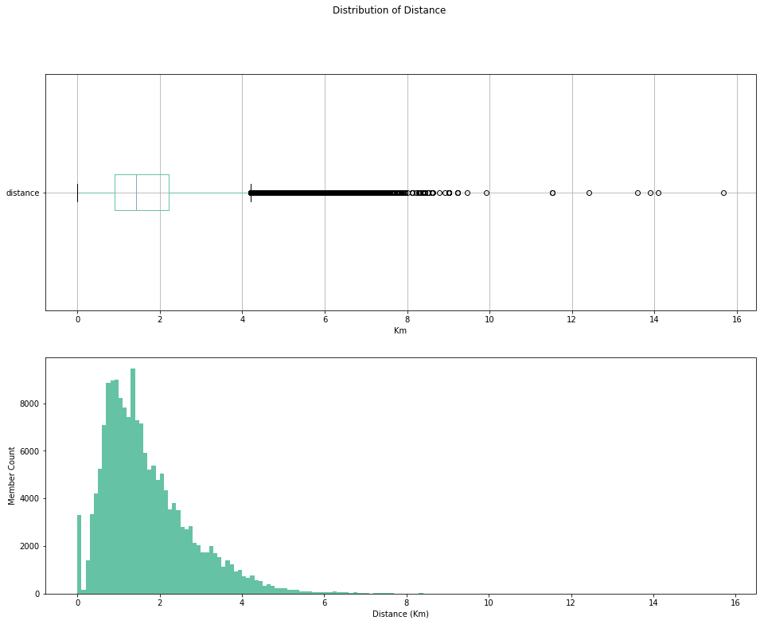

```python
# visualize the distance distribution using a boxplot and a histogram
fig, axes = plt.subplots(2, 1, figsize=(16,12));
fig.suptitle('Distribution of Distance');

plt.subplot(2, 1, 1)
boxplot(bike_df_copy, 'distance', 'Km')

plt.subplot(2, 1, 2)
binsize = 0.1
bins = np.arange(0., bike_df_copy['distance'].max()+binsize, binsize)
histogram(bike_df_copy, 'distance', 'Distance (Km)', 'Member Count', bins)
```

```python
# select high outliers, using visualizations
# extreme outliers based on the plot are distances > 9km

high_outliers_9 = (bike_df_copy['distance'] > 9)
print(bike_df_copy.loc[high_outliers_9,:])
```

```
       start_station_id               start_station_name end_station_id  \
13561               200             2nd Ave at E 18th St            254
19827               227   Foothill Blvd at Fruitvale Ave             21
39021               200             2nd Ave at E 18th St            254
47623               228  Foothill Blvd at Harrington Ave            248
50859               167       College Ave at Harwood Ave             22
60845               263    Channing Way at San Pablo Ave            225
87602                 9           Broadway at Battery St            193
88175               254          Vine St at Shattuck Ave            200
89787               201             10th St at Fallon St             15
92177               254          Vine St at Shattuck Ave            200
121514              230          14th St at Mandela Pkwy            223
130432              155         Emeryville Public Market            237
131842              200             2nd Ave at E 18th St            254
133206              254          Vine St at Shattuck Ave            200
```

[output cut: 68 more lines]

There are 19 outliers.

```python
# drop the outliers
bike_df_copy = bike_df_copy.loc[-high_outliers_9]
```

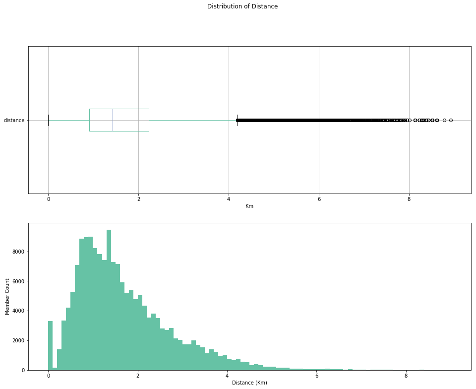

```python
# visualize the distance distribution for the new dataset
fig, axes = plt.subplots(2, 1, figsize=(16,12));
fig.suptitle('Distribution of Distance');

plt.subplot(2, 1, 1)
boxplot(bike_df_copy, 'distance', 'Km')

plt.subplot(2, 1, 2)
binsize = 0.1
bins = np.arange(0., bike_df_copy['distance'].max()+binsize, binsize)
histogram(bike_df_copy, 'distance', 'Distance (Km)', 'Member Count', bins)
```

The plots are logical based on the dataset. Therefore, I will not perform any transformation on this variable.

### 4. What is the distribution of the bike sharers by user type?

```python
# define a function to plot countplots for univariate exploration
def countplot(Dataframe, x_values, x_label, y_label, title):
    plt.figure(figsize=[8, 6])
    sb.countplot(data=Dataframe, x=x_values);
    plt.xlabel(x_label)
    plt.ylabel(y_label)
    plt.title(title, fontsize=15);
    plt.show()
```

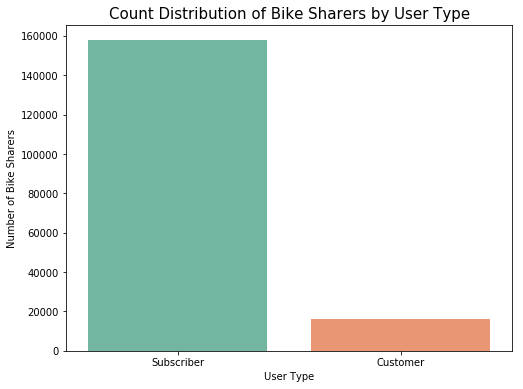

```python
# create the countplot visualization of bike sharers by user type
countplot(bike_df_copy, 'user_type', 'User Type', 'Number of Bike Sharers', 'Count Distribution of Bike Sharers by User Type')
```

The proportion of subscibers (>150000) is higher compared to the proportion of customers (< 20000). This is not surprising, and this is also why I would like to know the differences between both user types in terms of the selected variables.

```python
# define a function to plot pie charts
def piechart(Dataframe, x_values, title):
    plt.figure(figsize=[6,6])
    plt.pie(data=Dataframe, x=x_values, labels='index', autopct='%.0f%%', textprops={'fontsize': 16}, explode=explode);
    plt.title(title, fontsize=15);
    plt.legend(bbox_to_anchor=(1, 1.02), loc='lower left')
    plt.show();
```

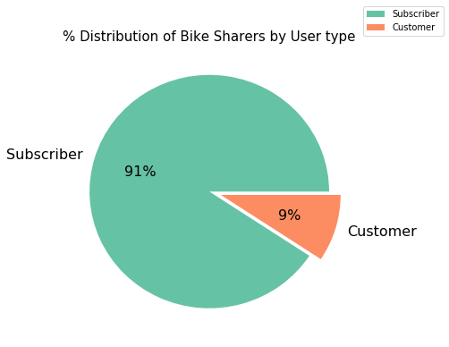

```python
# create a percentage visualization of the bike sharers by user type
#explode all
explode = (0, 0.1)
data = pd.DataFrame(bike_df_copy['user_type'].value_counts().reset_index())

#create pie chart
piechart(data, 'user_type', '% Distribution of Bike Sharers by User type')
```

91% of the bike sharers are subscribers and 9% are customers.

### 5. What is the distribution of the bike sharers by gender?

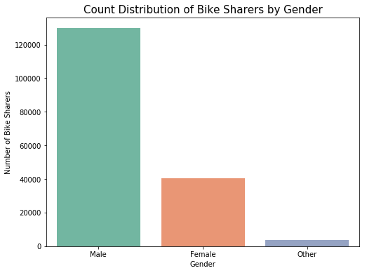

```python
# create the countplot visualization of bike sharers by gender
countplot(bike_df_copy, 'gender', 'Gender', 'Number of Bike Sharers', 'Count Distribution of Bike Sharers by Gender')
```

The majority of the bike sharers identified as males (>120000), about 40,000 identified as females, and less than 5000 identified as other. The proportion of males is not surprising because numerous research studies have established that males bike more than females for recreation and work.

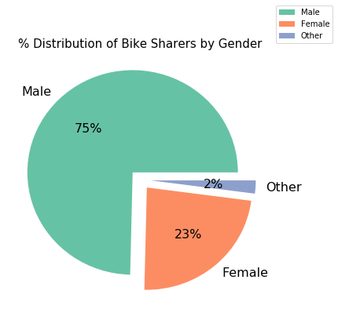

```python
# create a percentage visualization of the bike sharers by gender
#explode all
explode = (0.1, 0.1, 0.1)
data = pd.DataFrame(bike_df_copy['gender'].value_counts().reset_index())

#create pie chart
piechart(data, 'gender', '% Distribution of Bike Sharers by Gender')
```

75% of the bike sharers are males, 23% are females, and 2% identified as 'other'.

### 6. What is the distribution of trips by day category?

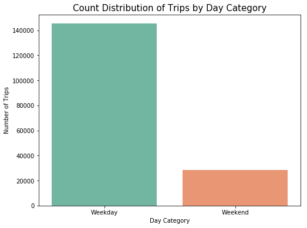

```python
# create the countplot visualization of trips by day category
countplot(bike_df_copy, 'day_week', 'Day Category', 'Number of Trips', 'Count Distribution of Trips by Day Category')
```

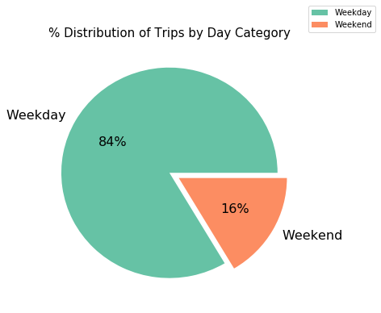

```python
# create a percentage visualization of the trips by day category
#explode all
explode = (0, 0.1)
data = pd.DataFrame(bike_df_copy['day_week'].value_counts().reset_index())

#create pie chart
piechart(data, 'day_week', '% Distribution of Trips by Day Category')
```

### 7. What is the distribution of trips by time category?

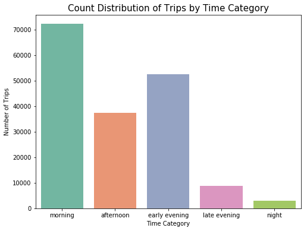

```python
# create the countplot visualization of trips by time category
countplot(bike_df_copy, 'time', 'Time Category', 'Number of Trips', 'Count Distribution of Trips by Time Category')
```

Majority of the trips occur in the mornings and early evenings, and the least number of trips are taken during the night.

### 8. What is the distribution of trips by days?

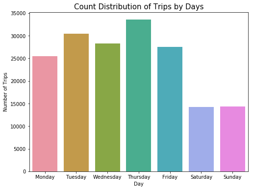

```python
# create the countplot visualization of trips by days
countplot(bike_df_copy, 'day_name', 'Day', 'Number of Trips', 'Count Distribution of Trips by Days')
```

The highest number of trips are taken on Thursday, followed by Tuesday and then Wednesday. The least number of trips are taken on Saturdays and Sundays.

### 9. What is the distribution of trips by bikes used for the entire trip?

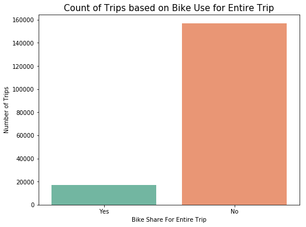

```python
countplot(bike_df_copy, 'bike_share_for_all_trip', 'Bike Share For Entire Trip', 'Number of Trips',
          'Count of Trips based on Bike Use for Entire Trip')
```

The majority of the bike sharers use the bike for only a part of their trips.

### Discuss the distribution(s) of your variable(s) of interest. Were there any unusual points? Did you need to perform any transformations?

The user type is a categorical variable with two categories namely 'Subscriber', and 'Customer'. 91% of the bike sharers are Subscribers, and the remaining 9% are Customers.

### Of the features you investigated, were there any unusual distributions? Did you perform any operations on the data to tidy, adjust, or change the form of the data? If so, why did you do this?

The numeric variables (age, distance, and duration) had unusual distributions at first glance because of the significant number of high outliers, most of which were removed from the dataset on the basis of the visualizations from the boxplot and histogram. The distributions for the numeric variables were skewed to the right, but no transformation was performed because the distributions accurately capture the dataset in logical reasoning. It is not unusual that the number of bike share trips were more concentrated around lower age, trip duration and station distance values, and it is also not unusual that the number of trips reduced as the identified numeric variables increased.

## Bivariate Exploration

In this section, I will attempt to determine the significant determinants of user type by exploring its relationship with the possible variables, explored individually in the previous section.

### 10. What are the differences between user types based on trip duration?

```python
# define a function to plot violinplots
def violinplot(Dataframe, x_values, x_label, y_values, y_label, title):
    plt.figure(figsize=[8, 6])
    sb.violinplot(data=Dataframe, x=x_values, y=y_values);
    plt.xlabel(x_label)
    plt.ylabel(y_label)
    plt.title(title, fontsize=15);
    plt.show()
```

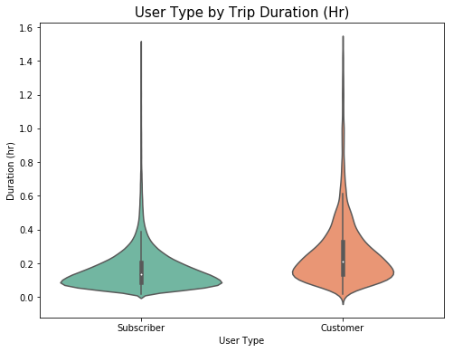

```python
# create a violin plot for user type vs trip duration
violinplot(bike_df_copy, 'user_type', 'User Type', 'duration_hr', 'Duration (hr)', 'User Type by Trip Duration (Hr)')
```

Based on the median and quartile, the trip duration for customers is significantly higher than that of subscribers. Additionally, the range for the trip durations differ significantly for customers (between 0.1hr and 1hr) and subscribers (between 0.1hr and 0.7hr). Furthermore, the probability that the trip duration of subscribers is 0.1hr (roughly 6mins) is very high. On the other hand, customers have a trip duration of 0.25km (roughly 15mins), and the probability is less than than of the subscribers. This is not surprising because subscribers tend to be daily commuters to a defined place of work or study, and some might need to travel longer distances than others. Therefore, it can be opined that trip duration might have an effect on user type. However, statistical analysis will be required to ascertain this assumption.

### 11. What are the differences between user types based on distance?

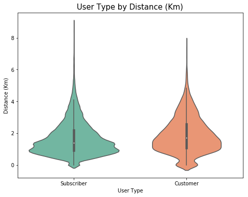

```python
violinplot(bike_df_copy, 'user_type', 'User Type', 'distance', 'Distance (Km)', 'User Type by Distance (Km)')
```

This insight can also imply the possibility of a correlation between trip duration and distance. This will not be surprising because distance is a part of the trip duration. Further exploration can confirm this assumption.

### 12. Is there any correlation between trip duration and distance?

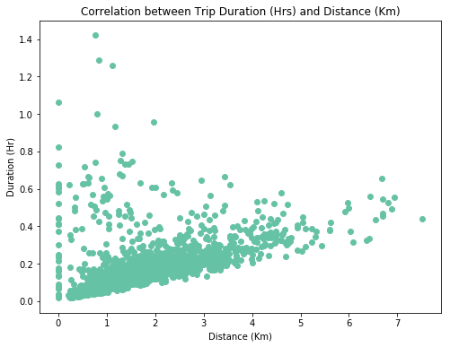

```python
plt.figure(figsize=[8,6])

# select a sample for the scatter plot to avoid overplotting as the population size is over 150000
bike_df_sample = bike_df_copy.sample(n=2000, replace = False)

plt.scatter(data = bike_df_sample, x='distance', y='duration_hr');

plt.title('Correlation between Trip Duration (Hrs) and Distance (Km)')
plt.xlabel('Distance (Km)')
plt.ylabel('Duration (Hr)')

plt.show()
```

The assumption has been confirmed as there is a moderate positive correlation between trip duration and distance. This implies that trip duration increases with distance. To ascertain causation, a regression plot will be helpful.

### 13. Does distance have an effect on trip duration?

```python
# perform a linear regression between trip duration and distance
import statsmodels.api as sm

X = bike_df_sample['distance']
y = bike_df_sample['duration_hr']

X2 = sm.add_constant(X)
est = sm.OLS(y, X2)
est2 = est.fit()
print(est2.summary())
```

```
                            OLS Regression Results
==============================================================================
Dep. Variable:            duration_hr   R-squared:                       0.232
Model:                            OLS   Adj. R-squared:                  0.232
Method:                 Least Squares   F-statistic:                     603.8
Date:                Sun, 13 Nov 2022   Prob (F-statistic):          1.00e-116
Time:                        00:06:00   Log-Likelihood:                 1456.4
No. Observations:                2000   AIC:                            -2909.
Df Residuals:                    1998   BIC:                            -2898.
Df Model:                           1
Covariance Type:            nonrobust
==============================================================================
                 coef    std err          t      P>|t|      [0.025      0.975]
------------------------------------------------------------------------------
const          0.0765      0.005     15.940      0.000       0.067       0.086
distance       0.0582      0.002     24.573      0.000       0.054       0.063
==============================================================================
Omnibus:                     1904.700   Durbin-Watson:                   1.916
Prob(Omnibus):                  0.000   Jarque-Bera (JB):            77989.867
Skew:                           4.572   Prob(JB):                         0.00
Kurtosis:                      32.194   Cond. No.                         4.39
==============================================================================

Warnings:
[1] Standard Errors assume that the covariance matrix of the errors is correctly specified.
```

[figure not shown]

```python
from sklearn import linear_model

# identify the data
x = bike_df_sample['distance'].values.reshape(-1,1)
y = bike_df_sample['duration_hr'].values

# create the regression model
ols = linear_model.LinearRegression()
model = ols.fit(x, y)
response = model.predict(x)

# evaluate the r2
r2 = model.score(x, y)

# visualize the regression model

fig, ax = plt.subplots(figsize=(8, 6))

ax.plot(x, response, color='k', label='Regression model')
ax.scatter(x, y, edgecolor='k', facecolor='green', alpha=0.7, label='Sample data')
ax.set_ylabel('Duration (Hr)', fontsize=14)
ax.set_xlabel('Distance (Km)', fontsize=14)
ax.legend(facecolor='white', fontsize=11)
ax.set_title('$R^2= %.2f$' % r2, fontsize=18)
ax.text(0.55, 0.15, '$y = %.2f x_1 - %.2f $' % (model.coef_[0], abs(model.intercept_)),  fontsize=17, transform=ax.transAxes)

fig.tight_layout()
```

From the regression equation, it can be concluded that a 1km increase in distance between start and end station will cause trip duration to increase by 0.06hr (about 3.6 minutes).

> Please note that the regression equation can change because of the random variable selection.

### 14. What are the differences between user types based on age?

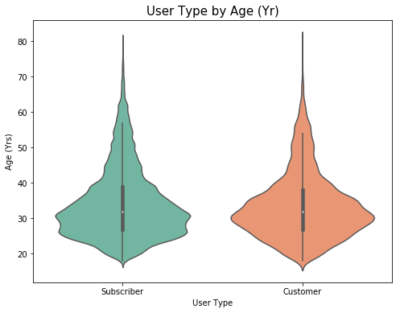

```python
violinplot(bike_df_copy, 'user_type', 'User Type', 'age', 'Age (Yrs)', 'User Type by Age (Yr)')
```

There is no significant difference between the median ages for customers and subscibers. The median age is about 32years for both user types. This implies that age does not impact the decision to be a subscriber or customer.

### 15. What are the differences between user types based on gender?

```python
# define a function to plot countplots for bivariate exploration
def countplotbi(Dataframe, x_values, x_label, y_label, hue, title, legend):
    plt.figure(figsize=[8, 6])
    sb.countplot(data=Dataframe, x=x_values, hue=hue);
    plt.xlabel(x_label)
    plt.ylabel(y_label)
    plt.legend(title=legend)
    plt.title(title, fontsize=15);
    plt.show()
```

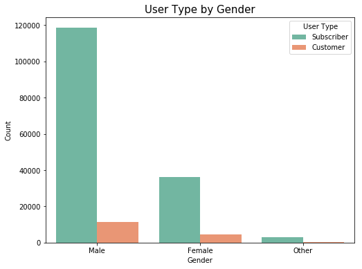

```python
countplotbi(bike_df_copy, 'gender', 'Gender', 'Count', 'user_type', 'User Type by Gender', 'User Type')
```

There are more male subscribers and customers compared to the other gender types. This is not surprising because of the proportion of males in the dataset, which has been justified by research. Therefore, gender does not affect user type.

### 16. What are the differences between user types based on trip time?

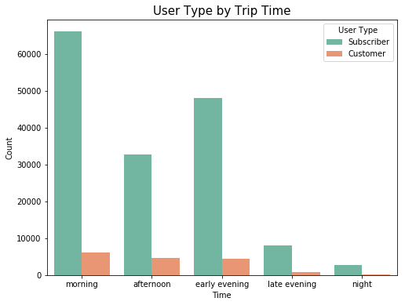

```python
countplotbi(bike_df_copy, 'time', 'Time', 'Count', 'user_type', 'User Type by Trip Time', 'User Type')
```

The majority of the bike share users, both customers and subscribers, take trips in the morning, afternoon and early evening. Therefore, the trip time does not affect user type. However, this information can be helpful for the provision of staff and number of bikes made available.

### 17. What are the differences between user types based on day category?

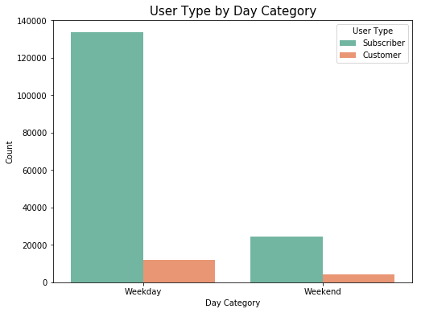

```python
countplotbi(bike_df_copy, 'day_week', 'Day Category', 'Count', 'user_type', 'User Type by Day Category', 'User Type')
```

A higher number of subscribers and customers use shared bikes during weekdays compared to the weekends. Day category has no effect on user type.

### 18. What are the differences between user types based on bike sharing for the entire trip?

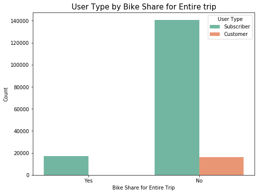

```python
countplotbi(bike_df_copy, 'bike_share_for_all_trip', 'Bike Share for Entire Trip', 'Count', 'user_type',
            'User Type by Bike Share for Entire trip', 'User Type')
```

It is interesting that only subscribers use the shared bike for an entire trip, while customers use the shared bike for only a part of their trips. The violin plots on user type by trip duration confirmed that subscribers tend to travel shorter distances compared with customers. And the conclusion was that subscribers tend to bike to a defined location for either work or school.

### Talk about some of the relationships you observed in this part of the investigation. How did the feature(s) of interest vary with other features in the dataset?

Only subscribers used the shared bike for an entire trip, while customers used the shared bike for only a part of their trips.

## Multivariate Exploration

Having discovered the determinants of user type, I will begin this part with an exploration of the possible relationships between the trip duration, distance, bike share for all trip, and other selected variables.

### 19. Is there any relationship between trip duration, distance and bike share for all trip?

The barplot from the bivariate data exploration established that only subscribers use the bike share for the entire trip. Therefore, the relationship between trip duration, distance and bike share for all trip can be attributed to the subscribers. However, to be certain, I will first plot the facet grid for both users before zooming in on the subscribers.

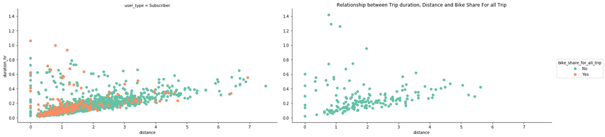

```python
g = sb.FacetGrid(bike_df_sample, col='user_type', hue='bike_share_for_all_trip', size = 5, aspect = 2);
g.map(plt.scatter, 'distance', 'duration_hr');
g.add_legend();

plt.title('Relationship between Trip duration, Distance and Bike Share For all Trip');
```

From the plots, it has been ascertained that only subscribers use the bike share for the entire trip. Now, we can focus on the subscribers plot.

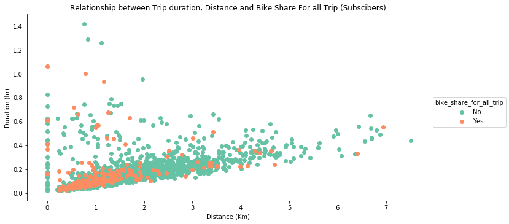

```python
g = sb.FacetGrid(data = bike_df_sample, hue = 'bike_share_for_all_trip', size = 5, aspect = 2);
g.map(plt.scatter, 'distance', 'duration_hr');
g.add_legend()

plt.title('Relationship between Trip duration, Distance and Bike Share For all Trip (Subscibers)');
plt.xlabel('Distance (Km)');
plt.ylabel('Duration (hr)');
```

The plot confirms the assumption that most subscribers travelled to a defined location either for study or work, and some travelled longer distances than others. The concentration of subscribers that used the bike share for the entire trip travelled between 0.2km and about 2km with a trip duration between 0.01 (less than a minute) and 0.2hrs (12mins). Some subscibers also returned the shared bikes to the start station.

### 20. Is there any relationship between trip duration, age and gender?

There are often research assertions that age and gender can affect trip duration for bikers. I would like to see if this holds true for this dataset.

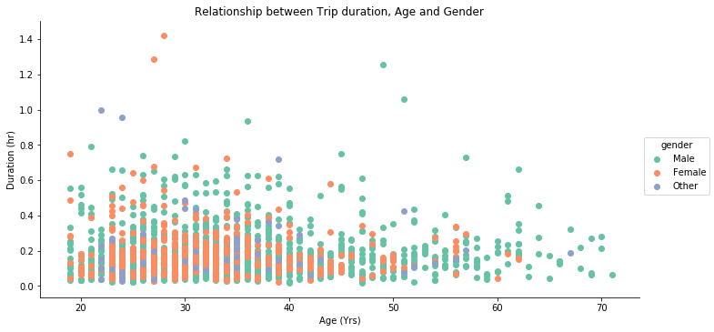

```python
g = sb.FacetGrid(data = bike_df_sample, hue = 'gender', size = 5, aspect = 2);
g.map(plt.scatter, 'age', 'duration_hr');
g.add_legend()

plt.title('Relationship between Trip duration, Age and Gender');
plt.xlabel('Age (Yrs)');
plt.ylabel('Duration (hr)');
```

First, there is no correlation between age and duration, which is very surprising. There is also no marked difference between the gender in terms of age and trip duration. It will be interesting to find out why this is the case for this dataset.

### 21. What are the differences between user types based on trip duration and gender?

```python
# define a function for plotting violinplots for multivariate exploration
def violinplotmul(Dataframe, x_values, x_label, y_values, y_label, hue, title, legend):
    plt.figure(figsize=[8, 6])
    sb.violinplot(data=Dataframe, x=x_values, y=y_values, hue=hue);
    plt.xlabel(x_label)
    plt.ylabel(y_label)
    plt.title(title, fontsize=15);
    plt.legend(title=legend, bbox_to_anchor=(1.3,0.5));
    plt.show()
```

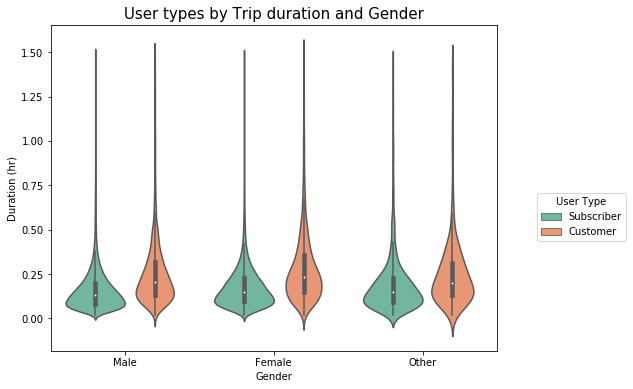

```python
violinplotmul(bike_df_copy, 'gender', 'Gender', 'duration_hr', 'Duration (hr)', 'user_type',
              'User types by Trip duration and Gender', 'User Type')
```

It is very interesting that the females (0.17hrs or 10mins) bike slightly longer than the males (0.14hrs or 8mins), and others (0.16hrs or 9mins) across user types. This is also a kind of deviation from current research trends. This dataset might reveal interesting research insights when explored further based on the context of the greater San Francisco Bay Area.

These results can also be related to distance between start and end stations since there is a significant relationship between trip duration and distance.

### 22. What are the differences between user types based on age and gender?

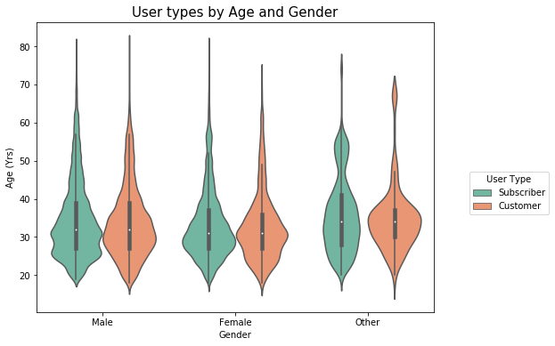

```python
violinplotmul(bike_df_copy, 'gender', 'Gender', 'age', 'Age (Yrs)', 'user_type',
              'User types by Age and Gender', 'User Type')
```

The median ages of others (35 years) are the highest, followed by that of the males (32 years), and lastly the females (30 years). These ranges indicate that the bike sharers across user types belong to the working class.

### 23. What are the differences between user types based on trip duration and day category?

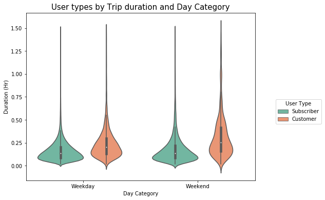

```python
violinplotmul(bike_df_copy, 'day_week', 'Day Category', 'duration_hr', 'Duration (Hr)', 'user_type',
              'User types by Trip duration and Day Category', 'User Type')
```

### 24. What are the differences between user types based on trip duration and time?

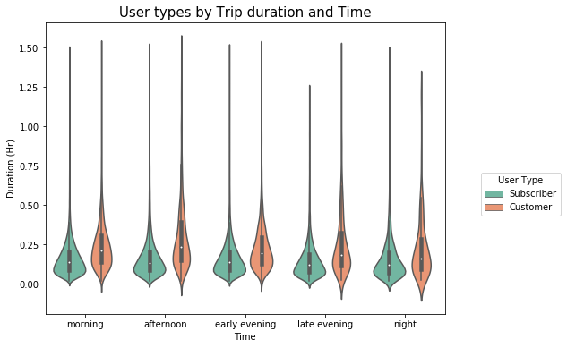

```python
violinplotmul(bike_df_copy, 'time', 'Time', 'duration_hr', 'Duration (Hr)', 'user_type',
              'User types by Trip duration and Time', 'User Type')
```

### Talk about some of the relationships you observed in this part of the investigation. Were there features that strengthened each other in terms of looking at your feature(s) of interest?

In this section, I zoomed in on the significant determinants of user type, discovered during the bivariate exploration. First, I considered the relationship between the identified determinants (duration_hr, distance, and bike_share_for_all_trip) based on the user types. As revealed earlier, only subscribers used the bike share for the entire trip, and the assumption that most subscribers travelled to a defined location either for study or work, and some travelled longer distances than others was confirmed. The identified determinants strengthened each other to provide deeper insight on the differences between customers and subscribers.

## Conclusions

```python
# save the final dataset used for the visulaizations to a csv file
bike_df_copy.to_csv('Fordgobike_final.csv', index=False)
```